# 4_land_use_changes (agnostic, config-driven)

```r
library(ebvcube)
library(tidyterra)
library(terra)
library(tidyverse)
library(graticule)
library(sf)
library(rworldmap)
library(ggplot2)
library(stringr)
library(yaml)

# Anchor wd to the notebook location (interactive use only;
# knitr sets root.dir to the document directory automatically)
if (requireNamespace("rstudioapi", quietly = TRUE) &&
    rstudioapi::isAvailable()) {
  setwd(dirname(rstudioapi::getSourceEditorContext()$path))
}
```

# 0. Configuration

The per-model contract — cube file path, entity → target class mapping, and which EBVcube metric to consume — lives in `../config/category_map.yaml`. Switching models is a single line: set `model_key` below to any key declared under `models:` in the YAML. The mapping and metric filter follow automatically.

```r
cfg <- yaml::read_yaml("../config/category_map.yaml")

# Single switch: pick the model whose cube to process
model_key   <- "GLOBIO"               # one of names(cfg$models)
model_label <- model_key

stopifnot(model_key %in% names(cfg$models))
mcfg <- cfg$models[[model_key]]

cat("Active model:   ", model_label, "\n")
```

```
Active model:    GLOBIO
```

```r
cat("Config version: ", cfg$version, "\n")
```

```
Config version:  1.0
```

# 1. Paths

Cube file path resolves as `paths$data_root + models[[model]]$file` from the YAML. The IPBES regions shapefile is discovered by recursive search under `data_root` (using the pre-simplified version produced previously with `simplifyGeom(tolerance = 0.05)`).

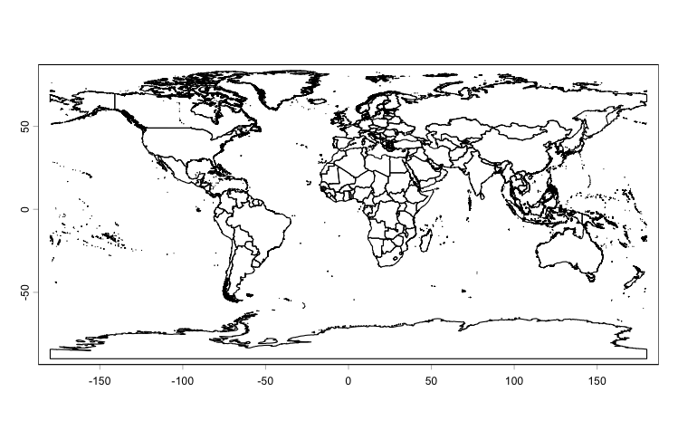

```r
cube_path <- file.path(cfg$paths$data_root, mcfg$file)
stopifnot(file.exists(cube_path))

root_LU_cubes <- cfg$paths$data_root

ipbes_shp <- list.files(root_LU_cubes, pattern = "\\.shp$",
                        full.names = TRUE, ignore.case = TRUE,
                        recursive  = TRUE)

# Reduced (pre-simplified) shape — produced once with:
# ipbesred <- simplifyGeom(vect(ipbes_full), tolerance = 0.05,
#                          preserveTopology = TRUE)
# writeVector(ipbesred, "../Data_geo/ipbes_regions_subregions/ipbes_reduced.shp")
ipbesred <- vect(ipbes_shp[1])
plot(ipbesred)
```

# 2. Cube metadata and metric filtering

PLUM cubes carry three metrics per scenario (protected / unprotected / total); other models may carry only one. The per-model `metric_filter` block in the YAML declares which metric path(s) to consume — everything downstream sees only the filtered set.

For PLUM the filter is `path_pattern: "metric_3/ebv_cube$"`, so the five-scenario list collapses from 15 rows to 5 (totals only). Setting `metric_filter: ~` in the YAML disables filtering for that model.

```r
cube_props     <- ebv_properties(cube_path,    verbose = FALSE)
cube_paths_all <- ebv_datacubepaths(cube_path, verbose = FALSE)

# Apply per-model metric filter
cube_paths <- if (!is.null(mcfg$metric_filter$path_pattern)) {
  cube_paths_all[grepl(mcfg$metric_filter$path_pattern,
                       cube_paths_all$datacubepaths), ]
} else if (!is.null(mcfg$metric_filter$keep)) {
  cube_paths_all[cube_paths_all$metric_names %in%
                 mcfg$metric_filter$keep, ]
} else {
  cube_paths_all
}

stopifnot(nrow(cube_paths) >= 1)

cat("Model:     ", model_label, "\n")
```

```
Model:      GLOBIO
```

```r
cat("Metrics retained after filter:\n")
```

```
Metrics retained after filter:
```

```r
print(unique(cube_paths$metric_names))
```

```
[1] "Land cover"
```

```r
cat("Scenarios retained after filter:\n")
```

```
Scenarios retained after filter:
```

```r
print(unique(cube_paths$scenario_names))
```

```
[1] "Nature for Nature"  "Nature as Culture"  "Nature for Society" "SSP2 RCP 6.0"
```

```r
cat("Entities:\n");   print(cube_props@general$entity_names)
```

```
Entities:
 [1] "Urban"                          "Cropland"                       "Potential secondary vegetation" "Agroforestry"
 [5] "Pasture"                        "Rangeland"                      "Forestry"                       "Secondary vegetation"
 [9] "Unmanaged forest"               "Shrubland/Grassland"            "Other"                          "Bare Areas"
```

```r
cat("Timesteps:\n");  print(cube_props@temporal$dates)
```

```
Timesteps:
[1] "2020-01-01" "2030-01-01" "2050-01-01" "2070-01-01"
```

```r
cat("EPSG:      ",    cube_props@spatial$epsg,       "\n")
```

```
EPSG:       4326
```

```r
cat("Resolution:",    cube_props@spatial$resolution, "\n")
```

```
Resolution: 0.5 0.5
```

```r
cat("Extent:    ",    cube_props@spatial$extent,     "\n")
```

```
Extent:     -180 180 -90 90
```

```r
print(cube_paths)
```

```
                 datacubepaths     scenario_names metric_names
1 scenario_1/metric_1/ebv_cube  Nature for Nature   Land cover
2 scenario_2/metric_1/ebv_cube  Nature as Culture   Land cover
3 scenario_3/metric_1/ebv_cube Nature for Society   Land cover
4 scenario_4/metric_1/ebv_cube       SSP2 RCP 6.0   Land cover
```

# 3. Category map for the active model

Original entity names differ between models, so each gets its own mapping from native classes to the six target classes (`Urban`, `Cropland`, `Secondary_vegetation`, `Permanent_crops`, `Pasture`, `Primary_vegetation`). Entities mapped to `~` (YAML null → R `NA`) are excluded from the habitat-area denominator before normalization (e.g. `Barren` in PLUM, since polar/desert/rock pixels would otherwise distort the regional richness estimates).

```r
category_map <- unlist(mcfg$entities)

# Normalize potential string-form nulls to true NA
category_map[category_map %in% c("", "NA")] <- NA_character_

if (length(category_map) == 0) {
  warning("category_map for '", model_label,
          "' is empty — fill it in the YAML before running sections 4-5.")
}

# Entities excluded from the recategorization sum
excluded_entities <- names(category_map)[is.na(category_map)]
if (length(excluded_entities) > 0) {
  cat("Excluded from habitat denominator (NA-mapped):\n")
  print(excluded_entities)
}

# Active map: only entries with a defined target class.
# This is the ONLY map used downstream for recategorization —
# NA-mapped entities are never summed into any target class.
category_map_active <- category_map[!is.na(category_map)]
new_categories       <- unique(category_map_active)

cat("Target classes produced for", model_label, ":\n")
```

```
Target classes produced for GLOBIO :
```

```r
print(new_categories)
```

```
[1] "Urban"                "Cropland"             "Secondary_vegetation" "Permanent_crops"      "Pasture"
[6] "Primary_vegetation"
```

```r
category_map
```

```
                         Urban                       Cropland Potential_secondary_vegetation                   Agroforestry
                       "Urban"                     "Cropland"         "Secondary_vegetation"              "Permanent_crops"
                       Pasture                      Rangeland                       Forestry           Secondary_vegetation
                     "Pasture"                      "Pasture"         "Secondary_vegetation"         "Secondary_vegetation"
              Unmanaged_forest            Shrubland_Grassland                          Other                     Bare_Areas
          "Primary_vegetation"           "Primary_vegetation"           "Primary_vegetation"           "Primary_vegetation"
```

# 4. Changes in area

Both the percentage-point and km² outputs below come from a single `ebv_read()` pass per entity — fractions are read once (section 4.1), then reused to derive km² (section 4.2) by multiplying by a latitude-varying pixel-area raster. No entity is read from the cube more than once.

## 4.1 Reading fractions and percentage-point change per decade

```r
# Select scenario by NAME, not row index — robust across models with
# different scenario counts/labels. Change scenario_choice to switch.
scenario_choice <- "Nature for Society"   # must match a value in cube_paths$scenario_names

scenario_row <- cube_paths[cube_paths$scenario_names == scenario_choice, ]
stopifnot(nrow(scenario_row) == 1)

dc_path <- scenario_row$datacubepaths

cat("Processing scenario:", scenario_row$scenario_names,
    "| metric:", scenario_row$metric_names, "\n")
```

```
Processing scenario: Nature for Society | metric: Land cover
```

```r
# Metadata (shared by both 4.1 and 4.2)
entity_names      <- cube_props@general$entity_names
safe_entity_names <- gsub("[[:space:]/]+", "_", entity_names)
timestep_labels_all <- format(as.Date(cube_props@temporal$dates), "%Y")
n_entities        <- length(entity_names)

t0_label <- "2020"
t1_label <- "2050"

t0_idx <- which(timestep_labels_all == t0_label)
t1_idx <- which(timestep_labels_all == t1_label)
keep_idx <- c(t0_idx, t1_idx)
timestep_labels <- timestep_labels_all[keep_idx]

# Read all original entities for t0 and t1 — single read, reused below
lu_frac <- vector("list", n_entities)
names(lu_frac) <- safe_entity_names

for (e in seq_len(n_entities)) {
  cat(sprintf("[%d/%d] %s\n", e, n_entities, entity_names[e]))
  frac <- ebv_read(
    filepath     = cube_path,
    datacubepath = dc_path,
    entity       = e,
    timestep     = keep_idx,
    ignore_RAM   = TRUE,
    verbose      = FALSE
  )
  names(frac) <- paste0(safe_entity_names[e], "_", timestep_labels)
  lu_frac[[safe_entity_names[e]]] <- frac
}
```

```
[1/12] Urban
[2/12] Cropland
[3/12] Potential secondary vegetation
[4/12] Agroforestry
[5/12] Pasture
[6/12] Rangeland
[7/12] Forestry
[8/12] Secondary vegetation
[9/12] Unmanaged forest
[10/12] Shrubland/Grassland
[11/12] Other
[12/12] Bare Areas
```

```r
cat("Done.", model_label, "-", n_entities, "entities x 2 timesteps.\n")
```

```
Done. GLOBIO - 12 entities x 2 timesteps.
```

```r
# Verify entity coverage of the category map
unmapped <- setdiff(names(lu_frac), names(category_map))
if (length(unmapped) > 0) {
  stop("Entities present in cube but missing from category_map: ",
       paste(unmapped, collapse = ", "),
       "\n -> add them to config/category_map.yaml under models$",
       model_key, "$entities")
}

# Recategorise: sum fractions across entities sharing a new category.
# NA-mapped entities are already excluded — category_map_active and
# new_categories come from section 3.
lu_frac_recat <- lapply(new_categories, function(new_cat) {
  old_entities  <- names(category_map_active)[category_map_active == new_cat]
  summed        <- Reduce(`+`, lu_frac[old_entities])
  names(summed) <- paste0(new_cat, "_", timestep_labels)
  summed
}) |> setNames(new_categories)

cat("Recategorised into", length(new_categories), "classes:\n")
```

```
Recategorised into 6 classes:
```

```r
print(new_categories)
```

```
[1] "Urban"                "Cropland"             "Secondary_vegetation" "Permanent_crops"      "Pasture"
[6] "Primary_vegetation"
```

```r
# Percentage-point change per decade
n_decades <- (as.numeric(t1_label) - as.numeric(t0_label)) / 10

lu_pct_change_per_decade <- lapply(names(lu_frac_recat), function(lu) {
  r  <- lu_frac_recat[[lu]]
  y0 <- r[[paste0(lu, "_", t0_label)]]
  y1 <- r[[paste0(lu, "_", t1_label)]]
  change_per_decade <- (y1 - y0) / n_decades
  names(change_per_decade) <-
    paste0(lu, "_pctchange_per_decade_", t0_label, "_", t1_label)
  change_per_decade
}) |> setNames(names(lu_frac_recat))

cat("Percentage-point change per decade computed for", model_label, ":\n")
```

```
Percentage-point change per decade computed for GLOBIO :
```

```r
print(names(lu_pct_change_per_decade))
```

```
[1] "Urban"                "Cropland"             "Secondary_vegetation" "Permanent_crops"      "Pasture"
[6] "Primary_vegetation"
```

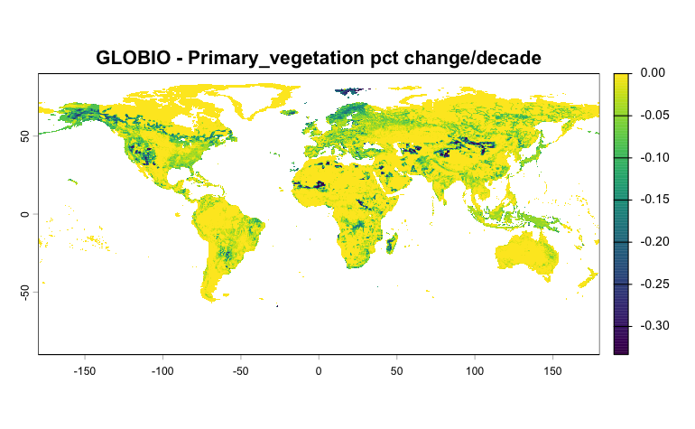

```r
plot(lu_pct_change_per_decade$Primary_vegetation,
     main = paste(model_label, "- Primary_vegetation pct change/decade"))
```

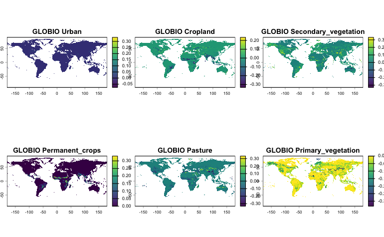

```r
pct_change_stack <- rast(lu_pct_change_per_decade)
plot(pct_change_stack, main = paste(model_label, names(pct_change_stack)))
```

## 4.2 Changes in km²

Fractions are converted to km² using a latitude-varying pixel-area raster (`terra::cellSize`), reusing the `lu_frac` already read in 4.1 — no second `ebv_read()` pass.

```r
# Pixel-area raster (latitude-varying), built once
pixel_area_km2 <- cellSize(
  rast(
    extent     = ext(cube_props@spatial$extent),
    resolution = cube_props@spatial$resolution,
    crs        = paste0("EPSG:", cube_props@spatial$epsg)
  ),
  unit = "km"
)

# Convert each already-read entity's fractions to km²
lu_area_km2 <- lapply(lu_frac, function(r) r * pixel_area_km2)
names(lu_area_km2) <- names(lu_frac)

cat("Converted to km² for", model_label, "-", length(lu_area_km2), "entities.\n")
```

```
Converted to km² for GLOBIO - 12 entities.
```

```r
# Recategorise: sum km² across entities sharing a new category
lu_area_km2_recat <- lapply(new_categories, function(new_cat) {
  old_entities  <- names(category_map_active)[category_map_active == new_cat]
  summed        <- Reduce(`+`, lu_area_km2[old_entities])
  names(summed) <- paste0(new_cat, "_", timestep_labels)
  summed
}) |> setNames(new_categories)

cat("Reclassified into", length(new_categories), "categories for",
    model_label, ":\n")
```

```
Reclassified into 6 categories for GLOBIO :
```

```r
print(new_categories)
```

```
[1] "Urban"                "Cropland"             "Secondary_vegetation" "Permanent_crops"      "Pasture"
[6] "Primary_vegetation"
```

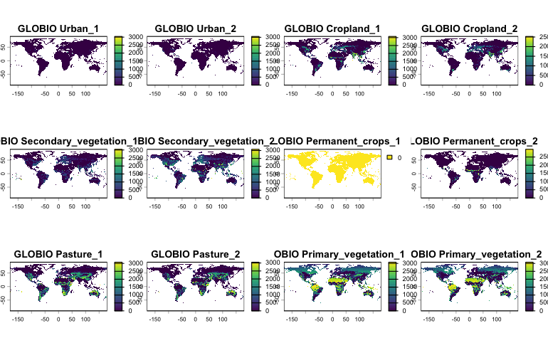

```r
lu_area_stack <- rast(lu_area_km2_recat)
plot(lu_area_stack, main = paste(model_label, names(lu_area_stack)))
```

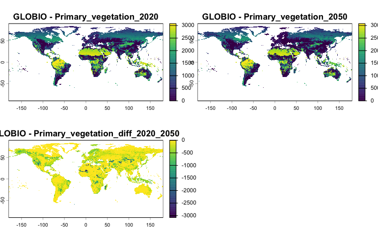

```r
# Primary_vegetation: t0, t1, and the difference (t1 - t0)
pv_t0 <- lu_area_km2_recat$Primary_vegetation[[paste0("Primary_vegetation_", t0_label)]]
pv_t1 <- lu_area_km2_recat$Primary_vegetation[[paste0("Primary_vegetation_", t1_label)]]
pv_diff <- pv_t1 - pv_t0
names(pv_diff) <- paste0("Primary_vegetation_diff_", t0_label, "_", t1_label)

pv_compare <- c(pv_t0, pv_t1, pv_diff)

plot(pv_compare,
     main = paste(model_label, "-", names(pv_compare)))
```